# Project 1: Wrangling, Exploration, Visualization

SDS322E

## Data Wrangling, Exploration, Visualization

### Lucas Amud loa267

#### Introduction

I will be working with two datasets. One encompasses fuel data for vehicles and the other covers government spending in different sectors. The vehicles dataset was sourced from the US Department of Energy (www.fueleconomy.gov). The infrastructure dataset was sourced from the US Bureau of Economic Analysis hosted by the US Department of Commerce (www.bea.gov). The vehicles dataset has a lot of columns. As a general overview, it provides information on make, model, year, city mpg, highway mpg, combined mpg, and many more statistics that give more insight into the vehicles and how environmentally-friendly they may be. The infrastructure dataset shows the real gross investment in 2012 chained million dollars for different sectors for every year. 2012 chained million dollars just means that the dollar amounts have been adjusted for inflation, with 2012 being the year that had no adjustment. This allows for fair comparison as inflation would positively skew more recent values compared to older ones.

Being an economics major, I thought it would be interesting to see government spending over time. I am also interested in cars so I looked for ways to connect these two subjects. An association that I would expect is that as government spending increased, the efficiency of cars improved. Admittedly, if a relationship exists, it could certainly be due to technological advances over time, but those would also benefit from government spending. It should also be interesting to see what other results arise from this exploration.

```r
# read your datasets in here, e.g., with read_csv()
library(tidyverse)
vehicles <- read_csv("https://www.fueleconomy.gov/feg/epadata/vehicles.csv")
infrastructure <- read_csv("~/project1/infrastructure-data-may-2020.csv")
infrastructure <- infrastructure %>% rename(type = Type)
# 83 col before
vehicles <- vehicles %>% select(-charge120, -fuelType2, -rangeA,
    -evMotor, -mfrCode, -c240Dscr, -c240bDscr, -startStop)  #removes rows that are all 0s
# 75 col after
```

#### Tidying: Reshaping

If your datasets are tidy already, demonstrate that you can reshape data with pivot wider/longer here (e.g., untidy and then retidy).

```r
# your tidying code (if applicable; can also wait until
# wrangling section)

infr <- infrastructure %>% pivot_longer(cols = -1, names_to = "year",
    values_to = "gross_inv") %>% distinct() %>% pivot_wider(names_from = "type",
    values_from = "gross_inv", values_fn = list(gross_inv = mean)) %>%
    arrange(desc(year))

# real gross investment in 2012 chained million dollars
```

In this section, I tidy the infrastructure dataset. For context, it shows each individual year as a column, and the rows represent the type or sector. I first pivot_longer, turning the year and values of every year (and sector) into their own columns (year and gross_inv). However, this results in the type being repeated for every row of year. Thus, I pivot_wider to get the sector names as individual columns, and pull the values from the just-created gross_inv column. This results in a column for year and columns for the sectors, with the values under the sector names matching up with the government spending for that year.

#### Joining/Merging

```r
glimpse(infr)
```

```
## Rows: 71
## Columns: 68
## $ year                                                               <chr> "2…
## $ `Total infrastructure`                                             <dbl> 79…
## $ `Total basic infrastructure`                                       <dbl> 30…
## $ `Total social infrastructure`                                      <dbl> 24…
## $ `Total digital infrastructure`                                     <dbl> 24…
## $ Private                                                            <dbl> 10…
## $ Federal                                                            <dbl> 26…
## $ `S&L`                                                              <dbl> 79…
## $ Water                                                              <dbl> 14…
## $ Sewer                                                              <dbl> 15…
## $ `Conservation and development`                                     <dbl> 78…
## $ Power                                                              <dbl> 14…
## $ Transportation                                                     <dbl> 12…
```

[output cut: 55 more lines]

```r
glimpse(vehicles)
```

```
## Rows: 44,329
## Columns: 75
## $ barrels08       <dbl> 15.69571, 29.96455, 12.20778, 29.96455, 17.34789, 14.…
## $ barrelsA08      <dbl> 0, 0, 0, 0, 0, 0, 0, 0, 0, 0, 0, 0, 0, 0, 0, 0, 0, 0,…
## $ charge240       <dbl> 0, 0, 0, 0, 0, 0, 0, 0, 0, 0, 0, 0, 0, 0, 0, 0, 0, 0,…
## $ city08          <dbl> 19, 9, 23, 10, 17, 21, 22, 23, 23, 23, 23, 18, 21, 18…
## $ city08U         <dbl> 0, 0, 0, 0, 0, 0, 0, 0, 0, 0, 0, 0, 0, 0, 0, 0, 0, 0,…
## $ cityA08         <dbl> 0, 0, 0, 0, 0, 0, 0, 0, 0, 0, 0, 0, 0, 0, 0, 0, 0, 0,…
## $ cityA08U        <dbl> 0, 0, 0, 0, 0, 0, 0, 0, 0, 0, 0, 0, 0, 0, 0, 0, 0, 0,…
## $ cityCD          <dbl> 0, 0, 0, 0, 0, 0, 0, 0, 0, 0, 0, 0, 0, 0, 0, 0, 0, 0,…
## $ cityE           <dbl> 0, 0, 0, 0, 0, 0, 0, 0, 0, 0, 0, 0, 0, 0, 0, 0, 0, 0,…
## $ cityUF          <dbl> 0, 0, 0, 0, 0, 0, 0, 0, 0, 0, 0, 0, 0, 0, 0, 0, 0, 0,…
## $ co2             <dbl> -1, -1, -1, -1, -1, -1, -1, -1, -1, -1, -1, -1, -1, -…
## $ co2A            <dbl> -1, -1, -1, -1, -1, -1, -1, -1, -1, -1, -1, -1, -1, -…
## $ co2TailpipeAGpm <dbl> 0, 0, 0, 0, 0, 0, 0, 0, 0, 0, 0, 0, 0, 0, 0, 0, 0, 0,…
```

[output cut: 62 more lines]

```r
infr <- infr %>% mutate(year = as.character(year))
vehicles <- vehicles %>% mutate(year = as.character(year))
# convert both columns to the same data type (from dbl)

merged <- inner_join(vehicles, infr, by = "year")
merged <- merged %>% relocate(year, .before = barrels08) %>%
    arrange(desc(year))

sum(infr$year %in% vehicles$year)
```

```
## [1] 34
```

```r
# is vehicles$year in infr$year

sum(vehicles$year %in% infr$year)
```

```
## [1] 38248
```

```r
vehicles %>% summarize(n_distinct(year))
```

```
## # A tibble: 1 x 1
##   `n_distinct(year)`
##                <int>
## 1                 39
```

```r
infr %>% summarize(n_distinct(year))
```

```
## # A tibble: 1 x 1
##   `n_distinct(year)`
##                <int>
## 1                 71
```

```r
merged %>% summarize(n_distinct(year))
```

```
## # A tibble: 1 x 1
##   `n_distinct(year)`
##                <int>
## 1                 34
```

```r
# which in left not on right for anti

anti_join(infr, vehicles, by = "year") %>% distinct(year) %>%
    arrange(year)  #year in infr not in vehicles
```

```
## # A tibble: 37 x 1
##    year
##    <chr>
##  1 1947
##  2 1948
##  3 1949
##  4 1950
##  5 1951
##  6 1952
##  7 1953
##  8 1954
##  9 1955
## 10 1956
## # … with 27 more rows
```

```r
anti_join(vehicles, infr, by = "year") %>% relocate(year, .before = barrels08) %>%
    distinct(year)  #year in vehicles not in infr
```

```
## # A tibble: 5 x 1
##   year
##   <chr>
## 1 2018
## 2 2019
## 3 2020
## 4 2021
## 5 2022
```

```r
merged
```

```
## # A tibble: 38,248 x 142
##    year  barrels08 barrelsA08 charge240 city08 city08U cityA08 cityA08U cityCD
##    <chr>     <dbl>      <dbl>     <dbl>  <dbl>   <dbl>   <dbl>    <dbl>  <dbl>
##  1 2017      14.3           0         0     20    20.2       0        0      0
##  2 2017      14.3           0         0     20    20.1       0        0      0
##  3 2017      15.0           0         0     19    19.4       0        0      0
##  4 2017      15.7           0         0     19    18.9       0        0      0
##  5 2017      15.7           0         0     19    18.7       0        0      0
##  6 2017       9.99          0         0     29    29.1       0        0      0
##  7 2017      10.3           0         0     28    28.2       0        0      0
##  8 2017      11.4           0         0     26    25.8       0        0      0
##  9 2017      15.7           0         0     18    18.2       0        0      0
## 10 2017      16.5           0         0     17    17.4       0        0      0
## # … with 38,238 more rows, and 133 more variables: cityE <dbl>, cityUF <dbl>,
## #   co2 <dbl>, co2A <dbl>, co2TailpipeAGpm <dbl>, co2TailpipeGpm <dbl>,
## #   comb08 <dbl>, comb08U <dbl>, combA08 <dbl>, combA08U <dbl>, combE <dbl>,
## #   combinedCD <dbl>, combinedUF <dbl>, cylinders <dbl>, displ <dbl>,
## #   drive <chr>, engId <dbl>, eng_dscr <chr>, feScore <dbl>, fuelCost08 <dbl>,
## #   fuelCostA08 <dbl>, fuelType <chr>, fuelType1 <chr>, ghgScore <dbl>,
## #   ghgScoreA <dbl>, highway08 <dbl>, highway08U <dbl>, highwayA08 <dbl>,
## #   highwayA08U <dbl>, highwayCD <dbl>, highwayE <dbl>, highwayUF <dbl>,
## #   hlv <dbl>, hpv <dbl>, id <dbl>, lv2 <dbl>, lv4 <dbl>, make <chr>,
## #   model <chr>, mpgData <chr>, phevBlended <lgl>, pv2 <dbl>, pv4 <dbl>,
## #   range <dbl>, rangeCity <dbl>, rangeCityA <dbl>, rangeHwy <dbl>,
## #   rangeHwyA <dbl>, trany <chr>, UCity <dbl>, UCityA <dbl>, UHighway <dbl>,
## #   UHighwayA <dbl>, VClass <chr>, youSaveSpend <dbl>, guzzler <lgl>,
## #   trans_dscr <chr>, tCharger <lgl>, sCharger <chr>, atvType <chr>,
## #   charge240b <dbl>, createdOn <chr>, modifiedOn <chr>, phevCity <dbl>,
## #   phevHwy <dbl>, phevComb <dbl>, `Total infrastructure` <dbl>, `Total basic
## #   infrastructure` <dbl>, `Total social infrastructure` <dbl>, `Total digital
## #   infrastructure` <dbl>, Private <dbl>, Federal <dbl>, `S&L` <dbl>,
## #   Water <dbl>, Sewer <dbl>, `Conservation and development` <dbl>,
## #   Power <dbl>, Transportation <dbl>, `Water supply` <dbl>, `Sewer and
## #   waste` <dbl>, `Electric power` <dbl>, `S&L electric power
## #   structures` <dbl>, `Federal electric power structures` <dbl>, `Private
## #   turbines/steam engines` <dbl>, `Private wind and solar power
## #   structures` <dbl>, `Private electrical transmission equipment` <dbl>,
## #   `Private electric power structures` <dbl>, `Natural gas /petroleum
## #   power` <dbl>, `S&L gas structures` <dbl>, `Private petroleum
## #   pipelines` <dbl>, `Private natural gas pipelines` <dbl>, `Highways and
## #   streets` <dbl>, `Air transportation` <dbl>, `Water transportation` <dbl>,
## #   `Rail transportation` <dbl>, Transit <dbl>, `Other federal` <dbl>, `Other
## #   private` <dbl>, `Air /water /other transportation` <dbl>, `S&L air
## #   transportation structures` <dbl>, …
```

The infrastructure (infr) and the vehicles (vehicles) dataset were joined using inner_join by the variable “year”. The two datasets cover very different information. An inner_join would be the most effective here because it only keeps the overlapping information (where the year in one matches the year in the other).

The dataset infr had 71 ‘year’ values (oriiginal distinct IDs). The merged dataset has 34. Thus, infr lost 71 - 34 = 37 values for year. This dataset does not repeat the years, so 37 rows were lost.

The infr datasets has no year values after 2017, so the years 2018-2022 are in vehicles but not in infr (5 distinct years dropped from vehicles). Similarly, the vehicles dataset has no year values before 1984, so the years 1947-1983 are in infr but not in vehicles (37 distinct years dropped from infr).

#### Wrangling

```r
library(knitr)
library(kableExtra)
delete_zero <- function(x) {
    mean(x == 0, na.rm = T) < 0.75
}


merged1 <- merged %>% mutate(year = as.numeric(year)) %>% mutate(electric = (ghgScore ==
    10 | fuelType == "Electricity")) %>% filter(electric == F) %>%
    select_if(delete_zero) %>% select(-createdOn, -modifiedOn)  #only electric and hybrids score 10 on EPA GHG

delete_nas <- function(x) {
    mean(is.na(x)) < 0.4
}

n_nas <- function(x) {
    sum(is.na(x))
}

merged1 <- merged1 %>% select_if(delete_nas)  #final selects columns that have NA ratio less than 0.4

merged1
```

```
## # A tibble: 38,025 x 95
##     year barrels08 city08   co2  co2A co2TailpipeGpm comb08 cylinders displ
##    <dbl>     <dbl>  <dbl> <dbl> <dbl>          <dbl>  <dbl>     <dbl> <dbl>
##  1  2017     14.3      20   388    -1            388     23         4   2
##  2  2017     14.3      20   396    -1            396     23         4   2
##  3  2017     15.0      19   410    -1            410     22         4   2
##  4  2017     15.7      19   425    -1            425     21         4   2
##  5  2017     15.7      19   419    -1            419     21         6   3
##  6  2017      9.99     29   272    -1            272     33         4   2
##  7  2017     10.3      28   282    -1            282     32         4   2
##  8  2017     11.4      26   301    -1            301     29         4   2
##  9  2017     15.7      18   427    -1            427     21         6   3.3
## 10  2017     16.5      17   457    -1            457     20         6   3.3
## # … with 38,015 more rows, and 86 more variables: drive <chr>, engId <dbl>,
## #   feScore <dbl>, fuelCost08 <dbl>, fuelType <chr>, fuelType1 <chr>,
## #   ghgScore <dbl>, ghgScoreA <dbl>, highway08 <dbl>, id <dbl>, lv4 <dbl>,
## #   make <chr>, model <chr>, mpgData <chr>, pv4 <dbl>, trany <chr>,
## #   UCity <dbl>, UHighway <dbl>, VClass <chr>, youSaveSpend <dbl>, `Total
## #   infrastructure` <dbl>, `Total basic infrastructure` <dbl>, `Total social
## #   infrastructure` <dbl>, `Total digital infrastructure` <dbl>, Private <dbl>,
## #   Federal <dbl>, `S&L` <dbl>, Water <dbl>, Sewer <dbl>, `Conservation and
## #   development` <dbl>, Power <dbl>, Transportation <dbl>, `Water
## #   supply` <dbl>, `Sewer and waste` <dbl>, `Electric power` <dbl>, `S&L
## #   electric power structures` <dbl>, `Federal electric power
## #   structures` <dbl>, `Private turbines/steam engines` <dbl>, `Private wind
## #   and solar power structures` <dbl>, `Private electrical transmission
## #   equipment` <dbl>, `Private electric power structures` <dbl>, `Natural gas
## #   /petroleum power` <dbl>, `S&L gas structures` <dbl>, `Private petroleum
## #   pipelines` <dbl>, `Private natural gas pipelines` <dbl>, `Highways and
## #   streets` <dbl>, `Air transportation` <dbl>, `Water transportation` <dbl>,
## #   `Rail transportation` <dbl>, Transit <dbl>, `Other federal` <dbl>, `Other
## #   private` <dbl>, `Air /water /other transportation` <dbl>, `S&L air
## #   transportation structures` <dbl>, `Private air transportation
## #   structures` <dbl>, `S&L water transportation structures` <dbl>, `Private
## #   water transportation structures` <dbl>, `Private other railroad/track
## #   replacement structures` <dbl>, `Other federal structures` <dbl>, `Private
## #   other land structures` <dbl>, `S&L rail equipment` <dbl>, `S&L motor
## #   vehicles` <dbl>, `S&L local transit structures` <dbl>, Social <dbl>,
## #   `Public safety` <dbl>, Education <dbl>, Health <dbl>, `Private
## #   hospitals` <dbl>, `S&L hospitals` <dbl>, `All federal` <dbl>, `Private
## #   other health structures` <dbl>, `S&L other health structures` <dbl>,
## #   `Private equipment` <dbl>, `S&L equipment` <dbl>, `S&L K-12` <dbl>, `S&L
## #   higher education` <dbl>, `S&L libraries` <dbl>, `S&L other educational
## #   structures` <dbl>, `S&L police` <dbl>, `S&L fire` <dbl>, `S&L
## #   correction` <dbl>, Digital <dbl>, `Private communications
## #   structures` <dbl>, `Private communications equipment in NAICS 515, 517,
## #   518, and 519` <dbl>, `Private software in NAICS 515, 517, 518, and
## #   519` <dbl>, `Private computers in NAICS 515, 517, 518, and 519` <dbl>
```

```r
merged1 %>% group_by(make, model, year) %>% group_by(n = n(),
    add = TRUE) %>% summarize_at("comb08", .funs = list(avgmpg = mean,
    sd = sd, var = var), na.rm = T) %>% relocate(n, .after = var)  #avg mpg per model per year with sd and var
```

```
## # A tibble: 17,004 x 7
## # Groups:   make, model, year [17,004]
##    make  model        year avgmpg     sd   var     n
##    <chr> <chr>       <dbl>  <dbl>  <dbl> <dbl> <int>
##  1 Acura 2.2CL/3.0CL  1997   22    2       4       3
##  2 Acura 2.3CL/3.0CL  1998   22    2       4       3
##  3 Acura 2.3CL/3.0CL  1999   22    2       4       3
##  4 Acura 2.5TL        1995   20   NA      NA       1
##  5 Acura 2.5TL/3.2TL  1996   19.5  0.707   0.5     2
##  6 Acura 2.5TL/3.2TL  1997   19.5  0.707   0.5     2
##  7 Acura 2.5TL/3.2TL  1998   19.5  0.707   0.5     2
##  8 Acura 3.2CL        2001   20   NA      NA       1
##  9 Acura 3.2CL        2002   21   NA      NA       1
## 10 Acura 3.2CL        2003   20.5  0.707   0.5     2
## # … with 16,994 more rows
```

```r
modelavgmpg <- merged1 %>% group_by(make, model) %>% group_by(n = n(),
    add = TRUE) %>% summarize_at("comb08", .funs = list(avgmpg = mean,
    sd = sd, var = var), na.rm = T) %>% relocate(n, .after = var)  #avg mpg per model (overall) with sd, var, and count (n)

kable(modelavgmpg %>% arrange(desc(avgmpg)), caption = "AvgMpg per Model per Make in Order of Best Avgmpg") %>%
    kable_classic(full_width = F, html_font = "Arial") %>% row_spec(1) %>%
    scroll_box(width = "800px", height = "800px")
```

AvgMpg per Model per Make in Order of Best Avgmpg

| make | model | avgmpg | sd | var | n |
| --- | --- | --- | --- | --- | --- |
| Toyota | Prius c | 50.000000 | NA | NA | 1 |
| Toyota | Prius Plug-in Hybrid | 50.000000 | NA | NA | 1 |
| Chevrolet | Sprint ER | 47.500000 | 0.7071068 | 0.5000000 | 2 |
| Chevrolet | Sprint Metro | 47.000000 | NA | NA | 1 |
| Geo | Metro XFI | 47.000000 | 0.0000000 | 0.0000000 | 5 |
| Honda | Insight | 46.500000 | 5.0118906 | 25.1190476 | 22 |
| Toyota | Prius | 45.416667 | 2.9374799 | 8.6287879 | 12 |
| Volkswagen | Jetta Hybrid | 44.000000 | NA | NA | 1 |
| Kia | Niro Touring | 43.000000 | NA | NA | 1 |
| Honda | Civic CRX HF | 42.142857 | 2.3487195 | 5.5164835 | 14 |
| Lexus | CT 200h | 42.000000 | 0.0000000 | 0.0000000 | 6 |
| Honda | Civic HB VX | 41.500000 | 1.6035675 | 2.5714286 | 8 |
| Hyundai | Sonata Hybrid SE | 41.500000 | 0.7071068 | 0.5000000 | 2 |
| Honda | Civic Hybrid | 41.105263 | 1.0485300 | 1.0994152 | 19 |
| Toyota | Prius v | 41.000000 | 0.0000000 | 0.0000000 | 5 |
| Ford | Fusion Hybrid FWD | 40.000000 | 1.6329932 | 2.6666667 | 7 |
| Lexus | ES 300h | 40.000000 | 0.0000000 | 0.0000000 | 4 |
| Toyota | Avalon Hybrid | 40.000000 | 0.0000000 | 0.0000000 | 4 |
| Toyota | Camry Hybrid LE | 40.000000 | 0.0000000 | 0.0000000 | 5 |
| Ford | C-MAX Hybrid FWD | 39.250000 | 0.5000000 | 0.2500000 | 4 |
| Suzuki | SA310 | 39.000000 | 4.2426407 | 18.0000000 | 2 |
| Toyota | Camry Hybrid XLE | 39.000000 | NA | NA | 1 |
| Lincoln | MKZ Hybrid FWD | 38.857143 | 1.0690450 | 1.1428571 | 7 |
| Toyota | Camry Hybrid XLE/SE | 38.750000 | 0.5000000 | 0.2500000 | 4 |
| Mercury | Milan Hybrid FWD | 38.500000 | 0.7071068 | 0.5000000 | 2 |
| Acura | ILX Hybrid | 38.000000 | 0.0000000 | 0.0000000 | 2 |
| Chevrolet | Sprint Plus | 38.000000 | 2.8284271 | 8.0000000 | 2 |
| Hyundai | Sonata Hybrid | 37.571429 | 1.7182494 | 2.9523810 | 7 |
| Pontiac | Firefly FE | 37.500000 | 3.5355339 | 12.5000000 | 2 |
| Kia | Optima Hybrid | 37.428571 | 2.0701967 | 4.2857143 | 7 |

[output cut: 3668 more lines]

```r
kable(modelavgmpg %>% group_by(make) %>% summarize(avgmpg = mean(avgmpg)) %>%
    filter(str_detect(make, "(.)\\1")) %>% distinct(make, avgmpg) %>%
    arrange(desc(avgmpg)), caption = "AvgMpg of Makes with Repeating Letters in Order of Best AvgMpg",
    digits = 2) %>% row_spec(1)
```

AvgMpg of Makes with Repeating Letters in Order of Best AvgMpg

| make | avgmpg |
| --- | --- |
| Grumman Olson | 28.75 |
| Daewoo | 22.80 |
| Nissan | 21.22 |
| Saab | 20.20 |
| Volga Associated Automobile | 19.00 |
| Jeep | 18.23 |
| Cadillac | 18.12 |
| TVR Engineering Ltd | 18.00 |
| Bill Dovell Motor Car Company | 17.50 |
| E. P. Dutton, Inc. | 17.00 |
| Grumman Allied Industries | 17.00 |
| Hummer | 15.16 |
| CCC Engineering | 15.00 |
| Saleen | 14.83 |
| Bitter Gmbh and Co. Kg | 14.58 |
| Mobility Ventures LLC | 14.33 |
| Wallace Environmental | 13.72 |
| Saleen Performance | 13.33 |
| Ferrari | 12.37 |
| Rolls-Royce | 11.31 |
| Bugatti | 10.00 |
| S and S Coach Company E.p. Dutton | 10.00 |
| Superior Coaches Div E.p. Dutton | 10.00 |

```r
# all makes with repeating letters, arranged by highest
# avgmpg

make_total <- merged1 %>% select(year, matches("gas|petroleum"),
    make, model, comb08) %>% mutate(total_gas = rowSums(across(.cols = matches("gas|petroleum")))) %>%
    group_by(make, year, total_gas, model) %>% group_by(n = n(),
    add = TRUE) %>% summarize_at("comb08", .funs = list(avgmpg = mean,
    sd = sd, var = var, median = median), na.rm = T) %>% relocate(n,
    .after = var) %>% relocate(model, .before = year) %>% relocate(year,
    .before = make) %>% mutate(na_count = n_nas(model))
# make, year, totalgas, avgmpg

year_gas <- merged1 %>% select(year, matches("gas|petroleum"),
    comb08) %>% mutate(total_gas = rowSums(across(.cols = matches("gas|petroleum")))) %>%
    group_by(year, total_gas) %>% group_by(n = n(), add = TRUE) %>%
    summarize_at("comb08", .funs = list(avgmpg = mean, sd = sd,
        var = var, median = median), na.rm = T) %>% relocate(n,
    .after = var) %>% mutate(na_count = n_nas(avgmpg))  # final no make no model, just year total_gas

year_gas %>% kbl() %>% kable_material() %>% scroll_box(width = "800px",
    height = "800px")
```

| year | total_gas | avgmpg | sd | var | n | median | na_count |
| --- | --- | --- | --- | --- | --- | --- | --- |
| 1984 | 18768 | 19.88187 | 5.332863 | 28.43943 | 1964 | 19 | 0 |
| 1985 | 22822 | 19.80835 | 5.238069 | 27.43737 | 1701 | 19 | 0 |
| 1986 | 22388 | 19.55041 | 5.184872 | 26.88290 | 1210 | 19 | 0 |
| 1987 | 22100 | 19.22855 | 5.045687 | 25.45896 | 1247 | 19 | 0 |
| 1988 | 23514 | 19.32832 | 4.981915 | 24.81948 | 1130 | 19 | 0 |
| 1989 | 26374 | 19.12576 | 5.102148 | 26.03191 | 1153 | 19 | 0 |
| 1990 | 28400 | 19.00093 | 4.899832 | 24.00836 | 1078 | 18 | 0 |
| 1991 | 33430 | 18.82597 | 4.833086 | 23.35872 | 1132 | 18 | 0 |
| 1992 | 40050 | 18.86262 | 4.848863 | 23.51147 | 1121 | 18 | 0 |
| 1993 | 33454 | 19.10430 | 4.832175 | 23.34992 | 1093 | 18 | 0 |
| 1994 | 27360 | 19.01222 | 4.567297 | 20.86020 | 982 | 18 | 0 |
| 1995 | 33712 | 18.79731 | 4.542219 | 20.63175 | 967 | 18 | 0 |
| 1996 | 26828 | 19.58473 | 4.596645 | 21.12914 | 773 | 19 | 0 |
| 1997 | 23988 | 19.42913 | 4.490708 | 20.16646 | 762 | 19 | 0 |
| 1998 | 39320 | 19.42892 | 4.391734 | 19.28733 | 809 | 19 | 0 |
| 1999 | 28028 | 19.36568 | 4.414539 | 19.48816 | 845 | 19 | 0 |
| 2000 | 24810 | 19.29545 | 4.375493 | 19.14494 | 836 | 19 | 0 |
| 2001 | 24740 | 19.24614 | 4.523983 | 20.46642 | 906 | 19 | 0 |
| 2002 | 29052 | 19.08736 | 4.456416 | 19.85964 | 973 | 19 | 0 |
| 2003 | 28866 | 18.94439 | 4.568814 | 20.87406 | 1043 | 19 | 0 |
| 2004 | 22554 | 19.06774 | 4.433154 | 19.65286 | 1122 | 19 | 0 |
| 2005 | 18922 | 19.19383 | 4.460046 | 19.89201 | 1166 | 19 | 0 |
| 2006 | 20330 | 18.95924 | 4.154012 | 17.25582 | 1104 | 19 | 0 |
| 2007 | 34776 | 18.97869 | 3.920033 | 15.36666 | 1126 | 19 | 0 |
| 2008 | 40096 | 19.20995 | 4.210367 | 17.72719 | 1186 | 19 | 0 |
| 2009 | 39528 | 19.73582 | 4.397377 | 19.33693 | 1181 | 20 | 0 |
| 2010 | 41344 | 20.59042 | 4.739882 | 22.46648 | 1106 | 20 | 0 |
| 2011 | 30992 | 20.75045 | 4.951876 | 24.52107 | 1122 | 20 | 0 |
| 2012 | 35954 | 21.34095 | 5.364441 | 28.77723 | 1138 | 21 | 0 |
| 2013 | 55392 | 21.88928 | 5.109528 | 26.10728 | 1147 | 21 | 0 |
| 2014 | 57916 | 22.34032 | 5.508827 | 30.34717 | 1193 | 22 | 0 |
| 2015 | 50658 | 22.71840 | 5.307281 | 28.16724 | 1250 | 22 | 0 |
| 2016 | 43800 | 23.03122 | 5.169083 | 26.71942 | 1217 | 22 | 0 |
| 2017 | 41526 | 23.05233 | 5.302729 | 28.11893 | 1242 | 23 | 0 |

```r
camaro_mpg1 <- make_total %>% filter(str_detect(make, "Chevrolet|Dodge"),
    str_detect(model, "Camaro|Challenger"), between(year, 2011,
        2016)) %>% group_by(year, make) %>% summarize_at("avgmpg",
    .funs = list(avgmpg = mean))
camaro_mpg1 %>% kbl() %>% kable_classic_2()
```

| year | make | avgmpg |
| --- | --- | --- |
| 2011 | Chevrolet | 20.40000 |
| 2011 | Dodge | 17.91667 |
| 2012 | Chevrolet | 18.71429 |
| 2012 | Dodge | 18.16667 |
| 2013 | Chevrolet | 18.57143 |
| 2013 | Dodge | 18.16667 |
| 2014 | Chevrolet | 18.12500 |
| 2014 | Dodge | 18.00000 |
| 2015 | Chevrolet | 18.12500 |
| 2015 | Dodge | 17.87500 |
| 2016 | Chevrolet | 21.83333 |
| 2016 | Dodge | 17.87500 |

```r
tmh <- make_total %>% filter(str_detect(make, "Honda|Toyota|Mazda"))

merged1 %>% filter(str_detect(model, "Camaro")) %>% filter(comb08 >
    20) %>% group_by(year, cylinders) %>% filter(year > 2010,
    year < 2017) %>% select(make, model, comb08) %>% arrange(desc(comb08)) %>%
    kbl() %>% kable_classic()  #4 cyl have high comb08
```

| year | cylinders | make | model | comb08 |
| --- | --- | --- | --- | --- |
| 2016 | 4 | Chevrolet | Camaro | 25 |
| 2016 | 4 | Chevrolet | Camaro | 24 |
| 2016 | 6 | Chevrolet | Camaro | 22 |
| 2015 | 6 | Chevrolet | Camaro | 22 |
| 2014 | 6 | Chevrolet | Camaro | 22 |
| 2013 | 6 | Chevrolet | Camaro | 22 |
| 2012 | 6 | Chevrolet | Camaro | 22 |
| 2012 | 6 | Chevrolet | Camaro | 22 |
| 2011 | 6 | Chevrolet | Camaro | 22 |
| 2011 | 6 | Chevrolet | Camaro | 22 |
| 2016 | 6 | Chevrolet | Camaro | 21 |
| 2015 | 6 | Chevrolet | Camaro | 21 |
| 2014 | 6 | Chevrolet | Camaro | 21 |
| 2013 | 6 | Chevrolet | Camaro | 21 |

#### Visualizing

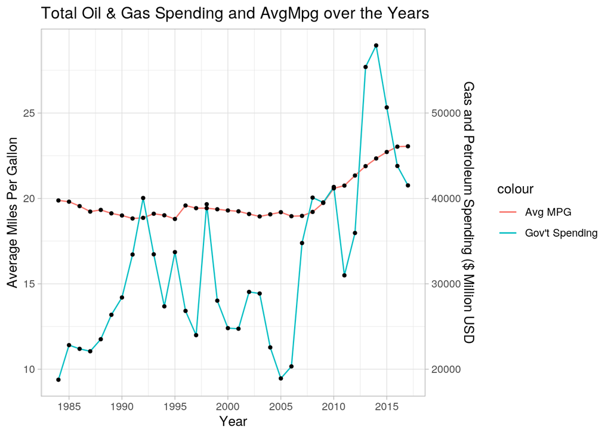

```r
coeff = 2000
year_gas %>% ggplot(aes(x = year)) + geom_line(aes(y = avgmpg,
    color = "Avg MPG")) + geom_line(aes(y = total_gas/coeff,
    color = "Gov't Spending"), label = "Total Gas") + geom_point(aes(y = avgmpg),
    size = 1) + geom_point(aes(y = total_gas/coeff), size = 1) +
    scale_x_continuous(n.breaks = 10) + scale_y_continuous(sec.axis = sec_axis(~. *
    coeff, name = "Gas and Petroleum Spending ($ Million USD")) +
    theme_light() + ggtitle("Total Oil & Gas Spending and AvgMpg over the Years") +
    ylab("Average Miles Per Gallon") + xlab("Year")
```

```r
# year vs total gas and avgmpg
```

Plot 1: This line plot shows time in years on the x-axis, average miles per gallon (avgmpg) on the y-axis, and total government spending in gas and petroleum on the secondary y-axis (scales adjusted accordingly). I initially theorized that increased government spending would lead to improvements in average mile per gallon over time. However, it seems as though AvgMpg were fairly constant from 1987 to around 2010 where it starts trending upwards. Around the same time, government spending in petroleum and gas sectors went up sharply from around $30000 million to over $55000 million from 2010 to 2014. Nonetheless, the improvements in average miles per gallon were most likely caused by the development of hybrid cars in the early 2000s.

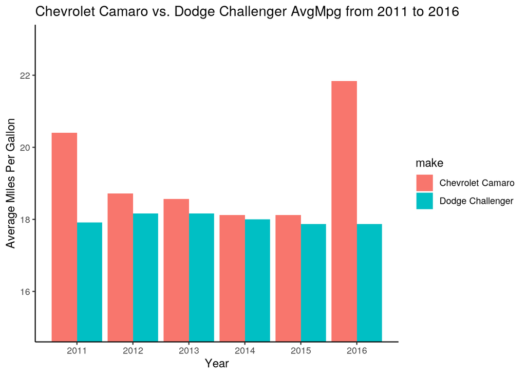

```r
camaro_mpg1 %>% ggplot(aes(year, avgmpg, fill = make)) + geom_bar(stat = "summary",
    position = "dodge") + scale_x_continuous(n.breaks = 6) +
    scale_y_continuous(breaks = (seq(10, 23, by = 2))) + coord_cartesian(ylim = c(15,
    23)) + scale_fill_discrete(name = "Model") + scale_fill_discrete(labels = c("Chevrolet Camaro",
    "Dodge Challenger")) + theme_classic() + ggtitle("Chevrolet Camaro vs. Dodge Challenger AvgMpg from 2011 to 2016") +
    ylab("Average Miles Per Gallon") + xlab("Year")
```

```r
# camaro released 4 cyl 2016
```

Plot 2: This bar plot shows the Average Miles Per Gallon on the y-axis and the years on the x-axis. This plot compares the average miles per gallon of the Chevrolet Camaro and the Dodge Challenger models in each year from 2011 to 2016. The Dodge Challenger saw very little variation in AvgMpg from 2011 to 2016, being around 18mpg for every year. The Chevrolet Camaro did have greater variance between the years, with clear spikes in 2011 and 2016. From 2012 to 2015, the Camaro and the Challenger were fairly close in AvgMpg at around 18-19. In 2016, Chevrolet released a more efficient Camaro model with a 4 cylinder engine. This is shown in the last table of the Wrangling section. This new model acted as an outlier and positively skewed the AvgMpg for Camaro in 2016 to around 21.8

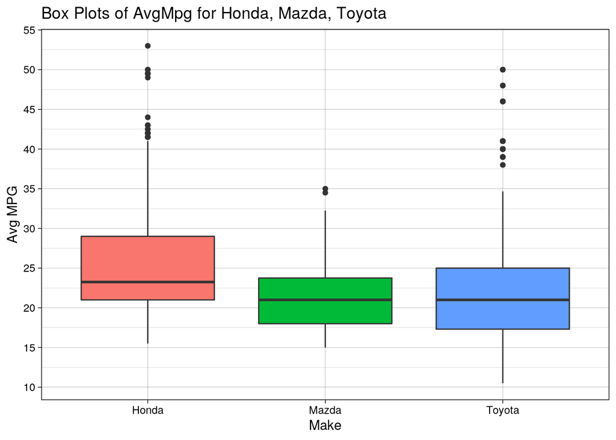

```r
tmh %>% ggplot(aes(x = make, y = avgmpg, fill = make)) + geom_boxplot() +
    theme_linedraw() + scale_y_continuous(breaks = (seq(5, 55,
    by = 5))) + xlab("Make") + ylab("Avg MPG") + theme(legend.position = "none") +
    ggtitle("Box Plots of AvgMpg for Honda, Mazda, Toyota")
```